# PostGIS

Mirko Mälicke

# 1 PostGIS

PostGIS is a PostgreSQL extension that offers several new datatypes for attribute declaration along with over 1000 predefined functions. The main new data type is called ‘GEOMETRY’ and can store any kind of OGR defined geometry object. The most important ones are the ‘Point’, ‘Line’ or ‘LineString’ and ‘Polygon’ geometry. A new table ‘spatial_ref_sys’ also created on PostGIS creation is prefilled with thousands of different CRS definitions. The functions can be used for any kind of spatial and geometrical manipulation and query as known from GIS systems. In fact, the PostgreSQL / PostGIS system is a full featured GIS system.  
CRS are stored in an ordinary table and can be queried just like you did it in the other lectures:

```sql
select * from spatial_ref_sys limit 5
```

| srid | auth_name | auth_srid | srtext | proj4text |
| --- | --- | --- | --- | --- |
| 3819 | EPSG | 3819 | GEOGCS["HD1909",DATUM["Hungarian_Datum_1909",SPHEROID["Bessel 1841",6377397.155,299.1528128,AUTHORITY["EPSG","7004"]],TOWGS84[595.48,121.69,515.35,4.115,-2.9383,0.853,-3.408],AUTHORITY["EPSG","1024"]]… | +proj=longlat +ellps=bessel +towgs84=595.48,121.69,515.35,4.115,-2.9383,0.853,-3.408 +no_defs |
| 3821 | EPSG | 3821 | GEOGCS["TWD67",DATUM["Taiwan_Datum_1967",SPHEROID["GRS 1967 Modified",6378160,298.25,AUTHORITY["EPSG","7050"]],AUTHORITY["EPSG","1025"]],PRIMEM["Greenwich",0,AUTHORITY["EPSG","8901"]],UNIT["degree",0.… | +proj=longlat +ellps=aust_SA +no_defs |
| 3824 | EPSG | 3824 | GEOGCS["TWD97",DATUM["Taiwan_Datum_1997",SPHEROID["GRS 1980",6378137,298.257222101,AUTHORITY["EPSG","7019"]],TOWGS84[0,0,0,0,0,0,0],AUTHORITY["EPSG","1026"]],PRIMEM["Greenwich",0,AUTHORITY["EPSG","890… | +proj=longlat +ellps=GRS80 +towgs84=0,0,0,0,0,0,0 +no_defs |
| 3889 | EPSG | 3889 | GEOGCS["IGRS",DATUM["Iraqi_Geospatial_Reference_System",SPHEROID["GRS 1980",6378137,298.257222101,AUTHORITY["EPSG","7019"]],TOWGS84[0,0,0,0,0,0,0],AUTHORITY["EPSG","1029"]],PRIMEM["Greenwich",0,AUTHOR… | +proj=longlat +ellps=GRS80 +towgs84=0,0,0,0,0,0,0 +no_defs |
| 3906 | EPSG | 3906 | GEOGCS["MGI 1901",DATUM["MGI_1901",SPHEROID["Bessel 1841",6377397.155,299.1528128,AUTHORITY["EPSG","7004"]],TOWGS84[682,-203,480,0,0,0,0],AUTHORITY["EPSG","1031"]],PRIMEM["Greenwich",0,AUTHORITY["EPSG… | +proj=longlat +ellps=bessel +towgs84=682,-203,480,0,0,0,0 +no_defs |

This looks quite simple. There is a srid, the primary key, which you should already know. The creators of PostGIS used the EPSG number as primary key. This is very handy as the ESPG identifiers are already unique. (and well known.)  
The *proj4text* field stores the CRS definition as a Poj4 string. This can be understood by most GIS system, like QGis, and recreate missing or custom CRS. The *srtext* field stores the WKT (well known text) definition of the CRS. This could be used to build the CRS by hand in other programming languages like Python, Perl or C++.  
Ok, then let’s see if all coordinate systems we might need are there:

```sql
select * from spatial_ref_sys where srid in (4326, 3857, 31467, 25832)
```

| srid | auth_name | auth_srid | srtext | proj4text |
| --- | --- | --- | --- | --- |
| 4326 | EPSG | 4326 | GEOGCS["WGS 84",DATUM["WGS_1984",SPHEROID["WGS 84",6378137,298.257223563,AUTHORITY["EPSG","7030"]],AUTHORITY["EPSG","6326"]],PRIMEM["Greenwich",0,AUTHORITY["EPSG","8901"]],UNIT["degree",0.017453292519… | +proj=longlat +datum=WGS84 +no_defs |
| 3857 | EPSG | 3857 | PROJCS["WGS 84 / Pseudo-Mercator",GEOGCS["WGS 84",DATUM["WGS_1984",SPHEROID["WGS 84",6378137,298.257223563,AUTHORITY["EPSG","7030"]],AUTHORITY["EPSG","6326"]],PRIMEM["Greenwich",0,AUTHORITY["EPSG","89… | +proj=merc +a=6378137 +b=6378137 +lat_ts=0.0 +lon_0=0.0 +x_0=0.0 +y_0=0 +k=1.0 +units=m +nadgrids=@null +wktext +no_defs |
| 25832 | EPSG | 25832 | PROJCS["ETRS89 / UTM zone 32N",GEOGCS["ETRS89",DATUM["European_Terrestrial_Reference_System_1989",SPHEROID["GRS 1980",6378137,298.257222101,AUTHORITY["EPSG","7019"]],TOWGS84[0,0,0,0,0,0,0],AUTHORITY["… | +proj=utm +zone=32 +ellps=GRS80 +towgs84=0,0,0,0,0,0,0 +units=m +no_defs |
| 31467 | EPSG | 31467 | PROJCS["DHDN / 3-degree Gauss-Kruger zone 3",GEOGCS["DHDN",DATUM["Deutsches_Hauptdreiecksnetz",SPHEROID["Bessel 1841",6377397.155,299.1528128,AUTHORITY["EPSG","7004"]],TOWGS84[598.1,73.7,418.2,0.202,0… | +proj=tmerc +lat_0=0 +lon_0=9 +k=1 +x_0=3500000 +y_0=0 +ellps=bessel +towgs84=598.1,73.7,418.2,0.202,0.045,-2.455,6.7 +units=m +no_defs |

# 2 Loading spatial data to R

You might have recognized, that RStudio is complaining about a not known datatype when querying the stations table from the database. This is due to the GEOMETRY data type, we introduced earlier. This is not known by the r package RPostgreSQL. Unlike Python, there is no easy way to make R or RStudio understand this datatype. Therefore, we will always have to load the geometries in the WKT format and convert it in R back to a binary spatial object as supported by the R packages you prefer.  
This is where the PostGIS funcitons set in. We can use any of them in SELECT statements or WHERE filters. In case you are familiar with the GDAL C++ or Python package, GRASS gis or any other command line based GIS solution, most of the PostGIS functions will be quite familiar to you. Otherwise you will have to search the documentation for the correct funciton names and usages.  
The WKT of any GEOMETRY object can be loaded with the *ST_AsEWKT* function:

```sql
select id, name, st_asewkt(geometry) from stations limit 5
```

| id | name | st_asewkt |
| --- | --- | --- |
| 257 | Baden_Baden_Geroldsau | SRID=25832;POINT(444535.254611277 5397382.7577233) |
| 259 | Muellheim | SRID=25832;POINT(398074.722190141 5295679.91278211) |
| 755 | Buchen_Kr_Neckar_Odenwald | SRID=25832;POINT(523255.907644743 5485113.81107755) |
| 1197 | Ellwangen_Rindelbach | SRID=25832;POINT(582755.474784241 5426905.02918657) |
| 1224 | Emmendingen_Mundingen | SRID=25832;POINT(413336.006163144 5332272.47419559) |

We can see two things here: First, we are able to read the coordinates now. Second, the raw WKT geometry information is prefixed by an iformation on the used CRS. This is a special PostGIS definition that might not be understood by all other GIS systems. The advantage is the ability of the system to store the geometry and CRS information in only one attribute. This also means, that there is no need to connect this table to the spatial_ref_sys table anymore. We could transform these coordinates on select.

```sql
select id, name, st_asewkt(geometry) as "UTM", st_asewkt(st_transform(geometry, 4326)) as "WGS84" from stations limit 5
```

| id | name | UTM | WGS84 |
| --- | --- | --- | --- |
| 257 | Baden_Baden_Geroldsau | SRID=25832;POINT(444535.254611277 5397382.7577233) | SRID=4326;POINT(8.24579999999998 48.727) |
| 259 | Muellheim | SRID=25832;POINT(398074.722190141 5295679.91278211) | SRID=4326;POINT(7.63869999999955 47.8063999999994) |
| 755 | Buchen_Kr_Neckar_Odenwald | SRID=25832;POINT(523255.907644743 5485113.81107755) | SRID=4326;POINT(9.3213 49.5182) |
| 1197 | Ellwangen_Rindelbach | SRID=25832;POINT(582755.474784241 5426905.02918657) | SRID=4326;POINT(10.1312000000002 48.9894999999998) |
| 1224 | Emmendingen_Mundingen | SRID=25832;POINT(413336.006163144 5332272.47419559) | SRID=4326;POINT(7.8350999999998 48.1377999999997) |

From here, we have several options to put the geometry information into a more usable format for R. We either load a package that can read WKT. Secondly, we could parse the Strings and extract the needed information ourselves or we could query the information in a more readable format for R.

Other languages like Python offer way more powerful bindings to databases. The SQLAlchemy and geoalchemy2 packages in Python, which are available in most scientific Python environments, can load, plot and manipulate PostGIS geometries out of the box.

```sql
select id, name, st_x(geometry) as lon, st_y(geometry) as lat from stations where geometry is not null
```

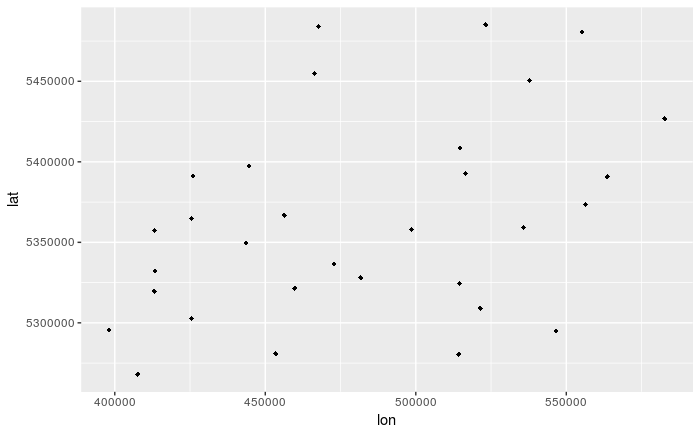

```r
ggplot(stations, aes(x=lon, y=lat)) + geom_point(shape=18)
```

# 3 Enabling spatial functions

One of the most important spatial funcitons is PostGIS ability to transform coordinates from and into any coordinate system defined in the spatial_ref_sys table. This is extremly helpful, when we want to combine our data with external datasources that force a specific CRS. Secondly, when applying spatial functions and calculating relations, distances or areas we must not use a not suitable CRS in order to prevent big calculation mistakes.  
PostGIS knows two helpful functions: *ST_Transform* for applying a transformation and *ST_SetCRS* for setting the CRS information in case they are missing in the GEOMETRY object.

```sql
select id, name, st_x(st_transform(geometry, 4326)) as lon, st_y(st_transform(geometry, 4326)) as lat
  from stations where geometry is not null
```

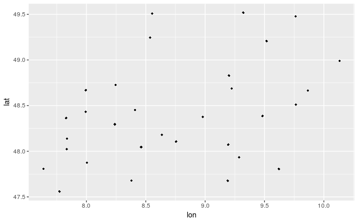

```r
ggplot(stations.wgs84, aes(x=lon, y=lat)) + geom_point(shape=18)
```

It is also possible to calculate distances in the database. Once calculated, these distance can be used like any other attribute, this means you can also sort or group by distances. Knowing this, it is for example easy to find the next station for a specific one, or any arbitraty location.  
Let’s find the Freiburg stations and search the database for the the closest and farest feature.

```sql
select * from stations where name like '%Freiburg%'
```

| id | name | elevation | geometry | description | discipline_id | hobo_id | influence |
| --- | --- | --- | --- | --- | --- | --- | --- |
| 1443 | Freiburg | 236 | 0101000020E8640000023B2B0E8D36194118A37ACADE4A5441 | NA | 1 | NA | NA |

```sql
select
  st_distance(geometry, (select geometry from stations where id=1443)) as distance,
  *
from stations
where id!=1443 and geometry is not null
order by distance ASC
```

| distance | id | name | elevation | geometry | description | discipline_id | hobo_id | influence |
| --- | --- | --- | --- | --- | --- | --- | --- | --- |
| 12727.66 | 1224 | Emmendingen_Mundingen | 201 | 0101000020E864000098A14F06603A19417138591E4C575441 | NA | 1 | NA | NA |
| 20787.31 | 1346 | Feldberg_Schwarzwald | 1490 | 0101000020E8640000F063216793F81941B8EEEF16973A5441 | NA | 1 | NA | NA |
| 28198.27 | 259 | Muellheim | 273 | 0101000020E8640000F8CF85E3EA4B1841AC056BFA8F335441 | NA | 1 | NA | NA |
| 37952.98 | 2812 | Lahr | 155 | 0101000020E864000064B97AEE22381941AC0B7400EF6F5441 | NA | 1 | NA | NA |
| 42661.24 | 5664 | Wolfach | 291 | 0101000020E86400004183C395B4121B4132B2F18D06685441 | NA | 1 | NA | NA |
| 46761.92 | 5229 | Villingen_Schwenningen | 720 | 0101000020E8640000AB84E29095101C41AB39C4F1C04C5441 | NA | 1 | NA | NA |
| 47031.74 | 1602 | Ohlsbach | 176 | 0101000020E8640000C4139214C3F819410EC094AF2A775441 | NA | 1 | NA | NA |
| 51818.77 | 4175 | Rheinfelden | 282 | 0101000020E86400003301A9A82BE118417460E4538C185441 | NA | 1 | NA | NA |
| 56010.79 | 5731 | Wutoeschingen_Ofteringen | 398 | 0101000020E864000075B61B537EAD1B41C6B1F7EDF6245441 | NA | 1 | NA | NA |
| 62184.59 | 4300 | Rottweil | 588 | 0101000020E8640000C36DCF6443DD1C41E92B1CA6735B5441 | NA | 1 | NA | NA |

[output cut: 20 more lines]

```sql
select 'closest' as description, id, name, distance / 1000 as "distance [km]" from
(select  st_distance(geometry, (select geometry from stations where id=1443)) as distance, id, name from stations
where id!=1443 and geometry is not null
order by distance ASC limit 1) t1
union
select 'farest' as description, id, name, distance / 1000 as "distance [km]" from
(select st_distance(geometry, (select geometry from stations where id=1443)) as distance, id, name from stations
where id!=1443 and geometry is not null
order by distance DESC limit 1) t2
```

| description | id | name | distance [km] |
| --- | --- | --- | --- |
| closest | 1224 | Emmendingen_Mundingen | 12.72766 |
| farest | 3257 | Mergentheim_Bad_Neunkirchen | 214.94246 |

It is also possible to subset the table and filter the stations to be within a specific distance to the Freiburg station (e.g. 25km).

```sql
select id, name from stations where st_distance(geometry, (select geometry from stations where id=1443)) <= 25000
```

| id | name |
| --- | --- |
| 1224 | Emmendingen_Mundingen |
| 1346 | Feldberg_Schwarzwald |
| 1443 | Freiburg |

```sql
select id, name from stations where st_within(geometry, st_buffer((select geometry from stations where id=1443), 25000))
```

| id | name |
| --- | --- |
| 1224 | Emmendingen_Mundingen |
| 1346 | Feldberg_Schwarzwald |
| 1443 | Freiburg |

These two solutions lead to an identical solution, but there is yet happening something very different. It is very good to have different ways of calculating the same result. The way PostgreSQL will find the selected features can be described as a query plan. This is esentially, what the computer is planning to do and, more important, why it came to these decisions. Therefore it is a very helpful tool to be able to print out these query plans when trying to identify dropping performances. Another helpful information of a query plan is the total runtime on the machine. This does not include the time the data needs to be transferred to your computer and the time a client application needs to visualize the data, which is usually the bottleneck but has nothing to do with the actual database performance.  
In PostgreSQL you can prefix any SELECT statement with EXPLAIN ANALYZE to make Postgres print out the query plan instead of the results.

```sql
explain analyze select id, name from stations where st_distance(geometry, (select geometry from stations where id=1443)) <= 25000
```

| QUERY PLAN |
| --- |
| Seq Scan on cstations (cost=5.93..44.12 rows=14 width=20) (actual time=0.048..0.078 rows=3 loops=1) |
| Filter: ((discipline_id = 1) AND (st_distance(geometry, $0) <= 25000::double precision)) |
| InitPlan 1 (returns $0) |
| -> Seq Scan on cstations (cost=0.00..5.93 rows=1 width=32) (actual time=0.004..0.031 rows=1 loops=1) |
| Filter: ((discipline_id = 1) AND (id = 1443)) |
| Total runtime: 0.094 ms |

```sql
explain analyze select id, name from stations where st_within(geometry, st_buffer((select geometry from stations where id=1443), 25000))
```

| QUERY PLAN |
| --- |
| Seq Scan on cstations (cost=5.93..76.05 rows=14 width=20) (actual time=0.458..2.302 rows=3 loops=1) |
| Filter: ((discipline_id = 1) AND st_within(geometry, st_buffer($0, 25000::double precision))) |
| InitPlan 1 (returns $0) |
| -> Seq Scan on cstations (cost=0.00..5.93 rows=1 width=32) (actual time=0.003..0.030 rows=1 loops=1) |
| Filter: ((discipline_id = 1) AND (id = 1443)) |
| Total runtime: 2.316 ms |

# 4 GIS in the database

The database includes several tables containing data uploaded from the WaBoA (Wasser- und Bodenatlas Baden-Württemberg). This is a major source for geodata in the region used by hydrologists quite frequently. Among others, you will find a table called *vegetation* cover there. Let’s have a look on that table.

```sql
select * from vegetation_cover limit 5
```

| id | description_id | geometry |
| --- | --- | --- |
| 1 | 25 | 0103000020E864000001000000110000002BAB8C45FE522041EB22F3B9D6…… |
| 2 | 5 | 0103000020E86400000100000009000000FF627211B55E2041B69521B9D6…… |
| 3 | 30 | 0103000020E86400000100000005000000E926DC0953C020410AFF4AB2D6FA544158D090706BBC2041092B91B2D6FA5441259AF3746BBC20415AABE398D0FB544186233F0E53C02041477C9D98D0FB5441E926DC0953C020410AFF4AB2D6FA5441 |
| 4 | 5 | 0103000020E864000001000000050000006806806D77E320418DE4D2AFD6FA5441171F35D48FDF20410B2D19B0D6FA5441726267D68FDF2041BC5D42A353FB54412663B26F77E32041AE13FCA253FB54416806806D77E320418DE4D2AFD6FA5441 |
| 5 | 35 | 0103000020E86400000100000005000000BD7160392EEF20410EF8FFAED6FA5441BCAF15A046EB20410F4A46AFD6FA5441493F48A246EB204115766FA253FB5441B21A933B2EEF20418A2229A253FB5441BD7160392EEF20410EF8FFAED6FA5441 |

The description_id seems to be a foreign key on a lookup table. To get a better insight, join the two tables and load the geometry in a human readable way.

```sql
select vc.id, d.name, st_asewkt(vc.geometry) from vegetation_cover vc join vegetation_cover_description d on vc.description_id=d.id limit 5
```

| id | name | st_asewkt |
| --- | --- | --- |
| 1 | mittel | SRID=25832;POLYGON((534911.135838841 5499738.90546487,534411.336425799 5499738.9097267,534411.344949623 5500738.5085324,533411.746119442 5500738.51705522,532911.946703818 5500738.5213155,532911.950963… |
| 2 | sehr gering bis gering | SRID=25832;POLYGON((536410.534075826 5499738.89267485,535910.734663856 5499738.89693895,534911.135838841 5499738.90546487,534911.144364178 5500738.50426986,535410.943778377 5500738.50000656,535410.939… |
| 3 | mittel bis hoch | SRID=25832;POLYGON((548905.519257751 5499738.78582741,548405.719854842 5499738.79011036,548405.728421037 5500738.38889583,548905.527825461 5500738.38461215,548905.519257751 5499738.78582741)) |
| 4 | sehr gering bis gering | SRID=25832;POLYGON((553403.713867378 5499738.74724687,552903.914467784 5499738.75153662,552903.918757512 5500238.55092567,553403.718157862 5500238.54663555,553403.713867378 5499738.74724687)) |
| 5 | mittel bis sehr hoch | SRID=25832;POLYGON((554903.112063937 5499738.73437311,554403.312665455 5499738.73866512,554403.316957452 5500238.53805306,554903.116356692 5500238.53376068,554903.112063937 5499738.73437311)) |

The geometry fields contain Polygons. We could instead use the area.

```sql
select vc.id, d.name, st_area(vc.geometry) from vegetation_cover vc join vegetation_cover_description d on vc.description_id=d.id limit 5
```

| id | name | st_area |
| --- | --- | --- |
| 1 | mittel | 3497192.3 |
| 2 | sehr gering bis gering | 999197.8 |
| 3 | mittel bis hoch | 499598.9 |
| 4 | sehr gering bis gering | 249799.4 |
| 5 | mittel bis sehr hoch | 249799.4 |

Another table from WaBoA is the catchment table (Einzugfsgebiete). These are all ‘official’ LUBW catchments. Note that these catchments do overlap, as they are derived on different levels. One thing we could do is join the catchment table to the stations table based on the location. The correct spatial query is a WITHIN or CONTAINS, based on which of both geometries you are querying against.

```sql
select * from stations s join einzugsgebiete ezg on st_within(s.geometry, ezg.geometry)
```

| id | name | elevation | geometry | description | discipline_id | hobo_id | influence | id | name | geometry | typ | vorflut | lv0 |
| --- | --- | --- | --- | --- | --- | --- | --- | --- | --- | --- | --- | --- | --- |
| 5906 | Mannheim | 96 | 0101000020E86400007F892ABA1D8C1C41E781933B9AEB5441 | NA | 1 | NA | NA | 40 | Rhein uh. Neckar oh. Pfrimm | 0103000020E8640000010000005902000064CB9C93DAFA1B4192443A8102…… | Zwg. | 2.000000e+12 | Oberrhein |
| 3257 | Mergentheim_Bad_Neunkirchen | 250 | 0101000020E86400001BBE72A99CF12041E889991557E85441 | NA | 1 | NA | NA | 109 | Althäuser Bach | 0103000020E864000001000000B9000000CB37F803A4DF20410DDE94B972…… | Ezg. | 2.465600e+12 | Main |
| 4703 | Sigmaringen_Laiz | 580 | 0101000020E8640000AE04A03689661F418DC5A479854F5441 | NA | 1 | NA | NA | 249 | Stelzenbach | 0103000020E864000001000000BB0000007639FE282C391F41A86AD3EB32…… | Ezg. | 1.000000e+12 | Donau |
| 755 | Buchen_Kr_Neckar_Odenwald | 340 | 0101000020E8640000969F6DA1DFEF1F41D4B1E8738EEC5441 | NA | 1 | NA | NA | 1879 | Bödigheimerbach | 0103000020E8640000010000004B0000005EA4A71650072041FD844440DB…… | Ezg. | 2.472400e+12 | Main |
| 3761 | Oehringen | 276 | 0101000020E86400007CA38126BC68204156EDF111D9CA5441 | NA | 1 | NA | NA | 440 | Ohrn uh. Schleifbach oh. Maßholderbach | 0103000020E864000001000000460000009B2F7EC5B25D2041D0BF00E1F6…… | Zwg. | 2.386780e+12 | Neckar |
| 1197 | Ellwangen_Rindelbach | 460 | 0101000020E86400008BEB16F3C6C821415631DE41B6B35441 | NA | 1 | NA | NA | 654 | Jagst uh. Kressbach oh. Fischbach | 0103000020E8640000010000009500000051C5E17E2CB621410F96825832…… | Zwg. | 2.388000e+12 | Neckar |
| 4928 | Stuttgart_Schnarrenberg | 314 | 0101000020E8640000CA5272FDDA691F416C024D4A9EA15441 | NA | 1 | NA | NA | 829 | Neckar uh. Nesenbach oh. Feuerbach | 0103000020E864000001000000CC000000EB6C44EA508B1F41B3A4AFBCCE…… | Zwg. | 2.380000e+12 | Neckar |
| 4887 | Stoetten | 734 | 0101000020E8640000CB92D7BA99332141B12392BF4F905441 | NA | 1 | NA | NA | 955 | Eyb oh. Magentalbach | 0103000020E864000001000000F1000000FF16665D6E2021414AB06656F1…… | Qug. | 2.382200e+12 | Neckar |
| 2814 | Merklingen | 685 | 0101000020E8640000B242EDC45AFB204146055EAF8F7F5441 | NA | 1 | NA | NA | 1098 | Kleine Lauter | 0103000020E864000001000000C80300009DC57CF28CE22041058D9E119C…… | Ezg. | 1.152000e+12 | Donau |
| 1468 | Freudenstadt | 797 | 0101000020E86400008B789EE9D5D91B41D0DC916D1C795441 | NA | 1 | NA | NA | 1138 | Forbach | 0103000020E864000001000000D90000001021979907CF1B412F56B5C770…… | Ezg. | 2.360000e+12 | Oberrhein |

[output cut: 21 more lines]

If you build your query like this, PostgreSQL will use the first matching feature from the einzugsgebiete table. To verify, that our results are correct, we need to count the instances, that do fulfill the connection conditional.

[output not shown]

```sql
select s.id, s.name, count(ezg.id) from stations s
  left outer join einzugsgebiete ezg on st_within(s.geometry, ezg.geometry)
group by s.id, s.name
```

| id | name | count |
| --- | --- | --- |
| 5731 | Wutoeschingen_Ofteringen | 1 |
| 4094 | Weingarten_Kr_Ravensburg | 1 |
| 259 | Muellheim | 1 |
| 1468 | Freudenstadt | 1 |
| 4703 | Sigmaringen_Laiz | 1 |
| 2638 | Klippeneck | 1 |
| 4169 | Rheinau_Memprechtshofen | 1 |
| 257 | Baden_Baden_Geroldsau | 1 |
| 755 | Buchen_Kr_Neckar_Odenwald | 1 |
| 2074 | Hechingen | 1 |

[output cut: 21 more lines]

# 5 cleanup

```r
dbDisconnect(con)
```

```
[1] TRUE
```